# Rapport expert: Prédiction du nombre de sinistres pour assurance responsabilité civile automobile

# 1 Présentation du projet

# 2 Analyse des données

## 2.1 Importation des données

On commençe par importer nos jeux de données `train` et `test`. Puis on affiche on les affiche afin d’observer l’allure des données.

```r
# Téléchargement du jeu de données
train<-read.csv('train_set.csv', header = T, sep = ",",dec=".")
test<-read.csv('test_set.csv', header = T, sep = ",",dec=".")

# Affichage du jeu de données sous forme de tableau
rmarkdown::paged_table(train)
```

| PolID | Claim | Period_Exp | Car_Power | Car_Age | Age | Bonus_Malus | Car_Model | Car_Fuel | Urban_rural_class | Inhab_density | French_region |
| --- | --- | --- | --- | --- | --- | --- | --- | --- | --- | --- | --- |
| 54009 | 4 | 0.560000000 | 4 | 4 | 46 | 50 | B4 | Diesel | A | 29 | Centre |
| 93954 | 5 | 1.000000000 | 7 | 9 | 67 | 50 | B2 | Diesel | E | 4762 | Provence-Alpes-Cotes-D'Azur |
| 2239279 | 8 | 0.410000000 | 4 | 12 | 52 | 50 | B1 | Regular | D | 824 | Languedoc-Roussillon |
| 3016883 | 4 | 0.270000000 | 5 | 9 | 23 | 90 | B3 | Diesel | E | 6924 | Ile-de-France |
| 3253234 | 11 | 0.080000000 | 4 | 13 | 53 | 50 | B1 | Regular | D | 824 | Languedoc-Roussillon |
| 4031494 | 4 | 0.100000000 | 4 | 1 | 31 | 85 | B12 | Regular | E | 2983 | Nord-Pas-de-Calais |
| 1198596 | 0 | 0.960000000 | 14 | 25 | 49 | 50 | B10 | Regular | E | 5053 | Ile-de-France |
| 1106349 | 0 | 0.730000000 | 10 | 2 | 38 | 51 | B12 | Diesel | C | 160 | Poitou-Charentes |
| 1085946 | 0 | 0.090000000 | 4 | 12 | 27 | 68 | B5 | Regular | C | 229 | Bretagne |
| 2079592 | 0 | 0.730000000 | 5 | 4 | 32 | 50 | B3 | Diesel | C | 461 | Bretagne |

[output cut: 9990 more lines]

```r
rmarkdown::paged_table(test)
```

| PolID | Period_Exp | Car_Power | Car_Age | Age | Bonus_Malus | Car_Model | Car_Fuel | Urban_rural_class | Inhab_density | French_region |
| --- | --- | --- | --- | --- | --- | --- | --- | --- | --- | --- |
| 1 | 0.100000000 | 5 | 0 | 55 | 50 | B12 | Regular | D | 1217 | Rhone-Alpes |
| 11 | 0.840000000 | 7 | 0 | 46 | 50 | B12 | Diesel | B | 76 | Aquitaine |
| 15 | 0.450000000 | 6 | 2 | 38 | 50 | B12 | Regular | E | 3003 | Nord-Pas-de-Calais |
| 17 | 0.270000000 | 7 | 0 | 33 | 68 | B12 | Diesel | C | 137 | Languedoc-Roussillon |
| 25 | 0.750000000 | 7 | 0 | 41 | 50 | B12 | Diesel | B | 60 | Pays-de-la-Loire |
| 27 | 0.870000000 | 7 | 0 | 56 | 50 | B12 | Diesel | C | 173 | Provence-Alpes-Cotes-D'Azur |
| 32 | 0.050000000 | 4 | 0 | 27 | 90 | B12 | Regular | D | 695 | Aquitaine |
| 49 | 0.810000000 | 7 | 0 | 73 | 50 | B12 | Regular | E | 3317 | Provence-Alpes-Cotes-D'Azur |
| 55 | 0.010000000 | 5 | 0 | 33 | 100 | B12 | Regular | D | 1746 | Ile-de-France |
| 62 | 0.870000000 | 5 | 0 | 54 | 50 | B12 | Regular | D | 781 | Nord-Pas-de-Calais |

[output cut: 9990 more lines]

Le train compte 542 389 lignes et 12 colonnes, tandis que le test compte 135 602 lignes et 11 colonnes, une de moins que le train puisqu’il manque la variable cible `claim`.

```r
summary(train)
```

```
##      PolID             Claim            Period_Exp         Car_Power
##  Min.   :      3   Min.   : 0.00000   Min.   :0.002732   Min.   : 4.000
##  1st Qu.:1157434   1st Qu.: 0.00000   1st Qu.:0.170000   1st Qu.: 5.000
##  Median :2271910   Median : 0.00000   Median :0.490000   Median : 6.000
##  Mean   :2620755   Mean   : 0.03894   Mean   :0.528595   Mean   : 6.454
##  3rd Qu.:4046150   3rd Qu.: 0.00000   3rd Qu.:0.990000   3rd Qu.: 7.000
##  Max.   :6114330   Max.   :11.00000   Max.   :2.010000   Max.   :15.000
##     Car_Age             Age          Bonus_Malus      Car_Model
##  Min.   :  0.000   Min.   : 18.00   Min.   : 50.00   Length:542389
##  1st Qu.:  2.000   1st Qu.: 34.00   1st Qu.: 50.00   Class :character
##  Median :  6.000   Median : 44.00   Median : 50.00   Mode  :character
##  Mean   :  7.036   Mean   : 45.49   Mean   : 59.77
##  3rd Qu.: 11.000   3rd Qu.: 55.00   3rd Qu.: 64.00
##  Max.   :100.000   Max.   :100.00   Max.   :228.00
##    Car_Fuel         Urban_rural_class  Inhab_density   French_region
##  Length:542389      Length:542389      Min.   :    1   Length:542389
##  Class :character   Class :character   1st Qu.:   92   Class :character
##  Mode  :character   Mode  :character   Median :  393   Mode  :character
##                                        Mean   : 1793
##                                        3rd Qu.: 1658
##                                        Max.   :27000
```

Ensuite on affiche un tableau qui présente le nom de chaque variable avec son type et le nombre de valeurs manquantes pour chacune d’entre elles.

```r
variable_summary_train <- data.frame(
  Type = sapply(train, class),
  Missing_Values = sapply(train, function(x) sum(is.na(x))))

variable_summary_train %>%
  kable(format = "html", caption = "Résumé des variables TRAIN") %>%
  kable_styling(bootstrap_options = c("striped", "hover", "condensed", "responsive"))
```

Table 2.1: Résumé des variables TRAIN

|  | Type | Missing_Values |
| --- | --- | --- |
| PolID | numeric | 0 |
| Claim | integer | 0 |
| Period_Exp | numeric | 0 |
| Car_Power | integer | 0 |
| Car_Age | integer | 0 |
| Age | integer | 0 |
| Bonus_Malus | integer | 0 |
| Car_Model | character | 0 |
| Car_Fuel | character | 0 |
| Urban_rural_class | character | 0 |
| Inhab_density | integer | 0 |
| French_region | character | 0 |

```r
# Résumé des variables pour le jeu de test
variable_summary_test <- data.frame(
  Type = sapply(test, class),
  Missing_Values = sapply(test, function(x) sum(is.na(x)))
)

# Affichage sous forme de tableau
variable_summary_test %>%
  kable(format = "html", caption = "Résumé des variables (TEST)") %>%
  kable_styling(bootstrap_options = c("striped", "hover", "condensed", "responsive"))
```

Table 2.2: Résumé des variables (TEST)

|  | Type | Missing_Values |
| --- | --- | --- |
| PolID | integer | 0 |
| Period_Exp | numeric | 0 |
| Car_Power | integer | 0 |
| Car_Age | integer | 0 |
| Age | integer | 0 |
| Bonus_Malus | integer | 0 |
| Car_Model | character | 0 |
| Car_Fuel | character | 0 |
| Urban_rural_class | character | 0 |
| Inhab_density | integer | 0 |
| French_region | character | 0 |

On remarque qu’il n’ y a pas de valeurs manquantes ni dans le train ni dans le test.

On sépare les variables numériques et catégorielles afin de faciliter les prochaines manipulations.

```r
#Division en variables numériques et catégorielles
numeric_cols <- c("Period_Exp", "Car_Power", "Car_Age", "Age", "Bonus_Malus", "Inhab_density")
categorical_cols <- c("Car_Model", "Car_Fuel", "Urban_rural_class", "French_region")
```

## 2.2 Observations des distributions

Observons la distribution de notre variable cible.

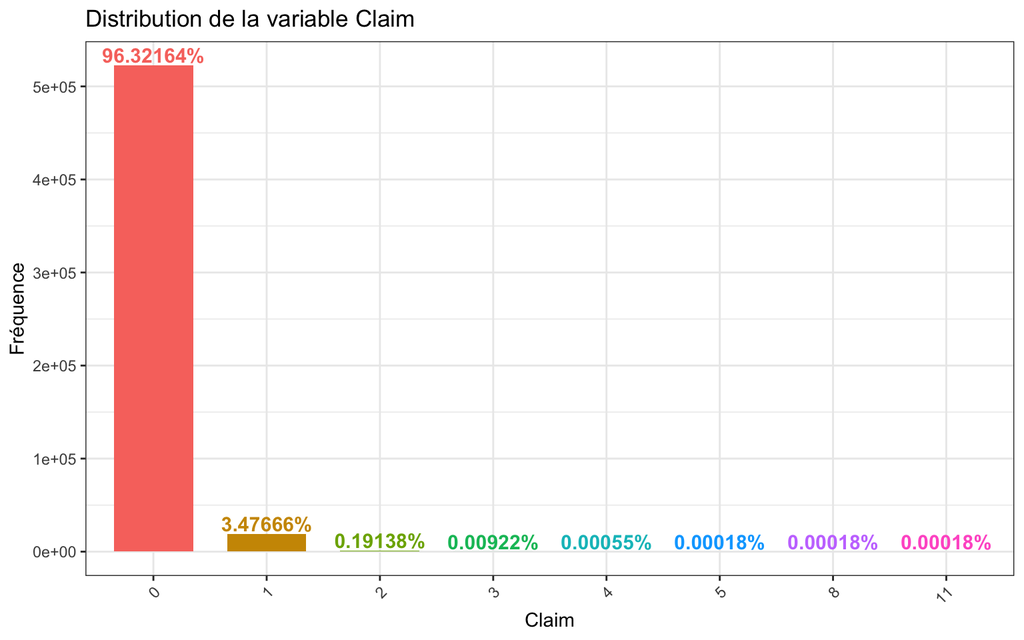

```r
# Distribution de la variable cible
plot_percentage(train,"Claim",5)
```

La distribution de la variable cible `Claim` montre un fort déséquilibre dans les données. En effet, 96.32% des contrats n’ont enregistré aucun sinistre, tandis que seulement 3.48% en comptent un, et les cas avec deux sinistres ou plus sont extrêmement rares (moins de 0.2%). Ce désiquilibre pose un défi en modélisation. Un modèle classique risque d’être biaisé en faveur des prédictions nulles, réduisant ainsi sa capacité à identifier les cas de sinistre.

Plusieurs stratégies peuvent alors être envisagées. On pourrait utiliser un modèle de comptage, comme une régression de Poisson ou une régression binomiale négative, qui sont adaptées aux variables discrètes et asymétriques. D’autre part, une approche basée sur le rééchantillonnage (sous-échantillonnage des contrats sans sinistre ou sur-échantillonnage des sinistres) pourrait améliorer l’apprentissage du modèle. Une autre alternative serait de transformer le problème en classification binaire (sinistre vs. pas de sinistre) avec une régression logistique.

Ensuite afin de visualiser nos données d’un point de vu géographique on affiche une carte colorée en fonction du nombre de sinitres totale pour chaque région du pays.

```r
# Créer le vecteur de correspondance
region_mapping <- c(`Ile-de-France` = "Île-de-France", `Champagne-Ardenne` = "Champagne-Ardenne",
    Picardie = "Picardie", `Haute-Normandie` = "Haute-Normandie", Centre = "Centre",
    `Basse-Normandie` = "Basse-Normandie", Bourgogne = "Bourgogne", `Nord-Pas-de-Calais` = "Nord-Pas-de-Calais",
    Lorraine = "Lorraine", Alsace = "Alsace", `Franche-Comte` = "Franche-Comté",
    `Pays-de-la-Loire` = "Pays de la Loire", Bretagne = "Bretagne", `Poitou-Charentes` = "Poitou-Charentes",
    Aquitaine = "Aquitaine", `Midi-Pyrenees` = "Midi-Pyrénées", Limousin = "Limousin",
    `Rhone-Alpes` = "Rhône-Alpes", Auvergne = "Auvergne", `Languedoc-Roussillon` = "Languedoc-Roussillon",
    `Provence-Alpes-Cotes-D'Azur` = "Provence-Alpes-Côte d'Azur", Corse = "Corse")

# Appliquer la correspondance aux noms de régions dans le jeu de données
train_old <- train %>%
    mutate(French_region = recode(French_region, !!!region_mapping))
```

```r
# Calcul du nombre total de Claim par région
old_claim_region <- train_old %>%
    group_by(French_region) %>%
    summarise(Total_Claim = sum(Claim))
old_france_map <- st_read("regions-avant-redecoupage-2015.geojson")
```

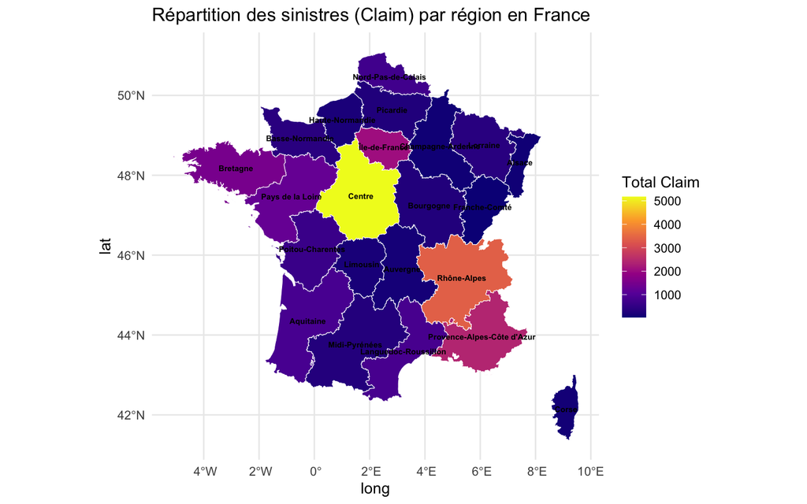

```r
# Joindre la carte avec les données
old_france_map <- old_france_map %>%
    left_join(old_claim_region, by = c(nom = "French_region"))

# Tracer la carte
centroides <- old_france_map %>%
    st_centroid() %>%
    mutate(long = st_coordinates(.)[, 1], lat = st_coordinates(.)[, 2])
ggplot(old_france_map) + geom_sf(aes(fill = Total_Claim), color = "white") + scale_fill_viridis_c(option = "C",
    na.value = "grey90") + geom_text(data = centroides, aes(x = long, y = lat, label = nom),
    color = "black", size = 2, fontface = "bold") + theme_minimal() + labs(title = "Répartition des sinistres (Claim) par région en France",
    fill = "Total Claim")
```

Cette distribution pourrait être influencée par la densité de la population et le nombre de clients assurés dans chaque région. Pour obtenir une représentation plus significative, nous avons normalisé le nombre de sinistres par 1000 souscripteurs, ce qui permet d’évaluer le risque réel par région indépendamment de la taille de la population assurée.

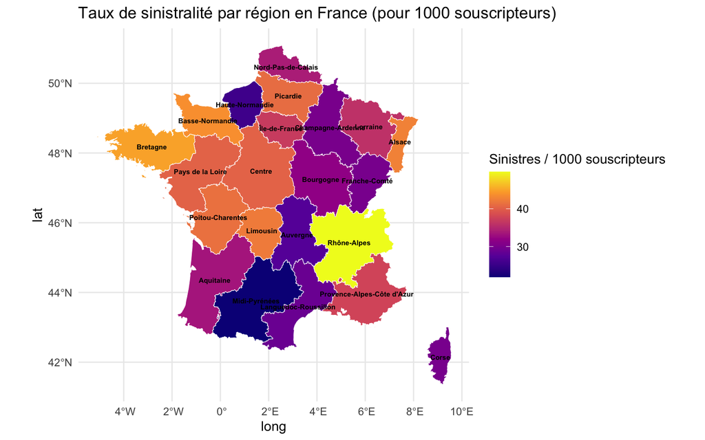

```r
old_risk_region <- train_old %>%
    group_by(French_region) %>%
    summarise(Total_Subscriptions = n(),
              Total_Claim = sum(Claim)) %>%
    mutate(Sinistralité_pour_1000 = (Total_Claim / Total_Subscriptions) * 1000)  # Normalisation
old_france_map <- old_france_map %>%
    left_join(old_risk_region, by = c(nom = "French_region"))
ggplot(old_france_map) +
    geom_sf(aes(fill = Sinistralité_pour_1000), color = "white") +  # Utilisation du taux
    scale_fill_viridis_c(option = "C", na.value = "grey90") +
    geom_text(data = centroides, aes(x = long, y = lat, label = nom),
              color = "black", size = 2, fontface = "bold") +
    theme_minimal() +
    labs(title = "Taux de sinistralité par région en France (pour 1000 souscripteurs)",
         fill = "Sinistres / 1000 souscripteurs")
```

Cette distribution pourrait être influencée par la densité de la population et le nombre de clients assurés dans chaque région. Cependant, une analyse brute du nombre total de sinistres peut être biaisée par ces disparités démographiques. Pour obtenir une représentation plus significative, nous avons normalisé le nombre de sinistres par 1000 souscripteurs, ce qui permet d’évaluer le risque réel par région indépendamment de la taille de la population assurée.

Sur la carte, on observe que certaines régions, comme Rhône-Alpes, présentent un taux de sinistralité particulièrement élevé, ce qui pourrait être lié à des facteurs tels que des conditions climatiques spécifiques, un réseau routier plus dense, ou des comportements de conduite propres à la région. À l’inverse, d’autres zones comme le Midi-Pyrénées et la Corse affichent des taux plus faibles, suggérant un risque de sinistre moins important par assuré.Cette analyse permet donc une meilleure identification des régions à risque, ce qui pourrait aider les assureurs à affiner leur politique tarifaire

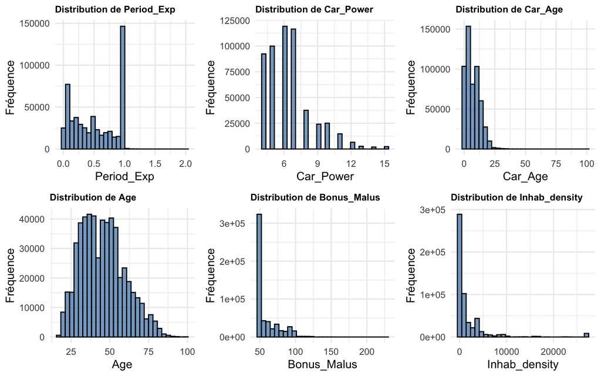

```r
plot_list <- list()

# Boucle sur chaque variable numérique
for (col in numeric_cols) {
  p <- ggplot(train, aes_string(x = col)) +
    geom_histogram(bins = 30, fill = "steelblue", color = "black", alpha = 0.7) +
    labs(title = paste("Distribution de", col), x = col, y = "Fréquence") +
    theme_minimal()+
    theme(plot.title = element_text(size = 9, face = "bold"))

  # Ajouter le graphique à la liste
  plot_list[[col]] <- p
}

# Afficher les graphiques (en 3 colonnes pour un affichage optimisé)
do.call("grid.arrange", c(plot_list, ncol = 3))
```

🔹 Period_Exp (Expérience d’assurance en années) La distribution est fortement asymétrique à droite, avec une majorité des souscripteurs ayant moins d’un an d’expérience. Un pic marqué autour de 1 pourrait être dû à une déclaration administrative fréquente. Une transformation logarithmique pourrait être envisagée pour lisser cette distribution.

🔹 Car_Age (Âge du véhicule) La majorité des véhicules ont moins de 10 ans, avec une répartition très asymétrique. Bien que certains véhicules plus anciens existent, ils sont en faible proportion. Une transformation par racine carrée pourrait améliorer la distribution et limiter l’influence des valeurs extrêmes.

🔹 Age (Âge du conducteur) La distribution suit une forme de cloche proche d’une loi normale, centrée autour de 45-50 ans. Les jeunes conducteurs (<25 ans) et les plus âgés (>75 ans) sont minoritaires. Il pourrait être intéressant d’introduire une variable catégorisant les conducteurs en classes d’âge.

🔹 Bonus_Malus (Système de réduction/augmentation de prime) La distribution est fortement asymétrique, avec un pic notable à 50, correspondant au minimum du système Bonus-Malus. Certains conducteurs ont des valeurs très élevées, mais ils restent minoritaires. Une transformation logarithmique pourrait aider à mieux capturer cette variabilité.

🔹 Inhab_density (Densité de population de la région du souscripteur) On observe une distribution extrêmement asymétrique, où la plupart des valeurs sont proches de zéro, correspondant aux zones rurales, tandis que quelques valeurs très élevées indiquent les grandes villes. Une transformation logarithmique est nécessaire pour limiter l’impact des valeurs extrêmes sur l’analyse.

## 2.3 Transformation des données

Tout d’abord, on remarque que la variable `PolID`ne sert à rien pour l’analyse donc on l’a supprime directement.

```r
#Supprimer la variable PolID
train <- subset(train, select = -PolID)
test <- subset(test, select = -PolID)
```

On commence par regarder les variables catégorielles pour voir comment nous allons les encoder.

```r
train [categorical_cols]
```

```
##       Car_Model Car_Fuel Urban_rural_class               French_region
## 1            B4   Diesel                 A                      Centre
## 2            B2   Diesel                 E Provence-Alpes-Cotes-D'Azur
## 3            B1  Regular                 D        Languedoc-Roussillon
## 4            B3   Diesel                 E               Ile-de-France
## 5            B1  Regular                 D        Languedoc-Roussillon
## 6           B12  Regular                 E          Nord-Pas-de-Calais
## 7           B10  Regular                 E               Ile-de-France
## 8           B12   Diesel                 C            Poitou-Charentes
## 9            B5  Regular                 C                    Bretagne
## 10           B3   Diesel                 C                    Bretagne
## 11          B12  Regular                 E Provence-Alpes-Cotes-D'Azur
## 12          B12   Diesel                 D          Nord-Pas-de-Calais
## 13          B12   Diesel                 A                   Aquitaine
## 14           B2   Diesel                 E                   Bourgogne
```

[output cut: 24986 more lines]

```r
# Nombre de catégories par variable
cat_counts_train <- sapply(train[categorical_cols], function(x) length(unique(x)))
cat_counts_test <- sapply(test[categorical_cols], function(x) length(unique(x)))
print(cat_counts_train)
```

```
##         Car_Model          Car_Fuel Urban_rural_class     French_region
##                11                 2                 6                22
```

```r
print(cat_counts_test)
```

```
##         Car_Model          Car_Fuel Urban_rural_class     French_region
##                11                 2                 6                22
```

On transforme les quatre variables catégorielles en facteurs car ceci marche bien pour les modèles régression

```r
# Transformer les variables catégorielles en facteurs
train[categorical_cols] <- lapply(train[categorical_cols], as.factor)
test[categorical_cols] <- lapply(test[categorical_cols], as.factor)
```

```r
#Vérification
str(test)
```

```
## 'data.frame':    135602 obs. of  10 variables:
##  $ Period_Exp       : num  0.1 0.84 0.45 0.27 0.75 0.87 0.05 0.81 0.01 0.87 ...
##  $ Car_Power        : int  5 7 6 7 7 7 4 7 5 5 ...
##  $ Car_Age          : int  0 0 2 0 0 0 0 0 0 0 ...
##  $ Age              : int  55 46 38 33 41 56 27 73 33 54 ...
##  $ Bonus_Malus      : int  50 50 50 68 50 50 90 50 100 50 ...
##  $ Car_Model        : Factor w/ 11 levels "B1","B10","B11",..: 4 4 4 4 4 4 4 4 4 4 ...
##  $ Car_Fuel         : Factor w/ 2 levels "Diesel","Regular": 2 1 2 1 1 1 2 2 2 2 ...
##  $ Urban_rural_class: Factor w/ 6 levels "A","B","C","D",..: 4 2 5 3 2 3 4 5 4 4 ...
##  $ Inhab_density    : int  1217 76 3003 137 60 173 695 3317 1746 781 ...
##  $ French_region    : Factor w/ 22 levels "Alsace","Aquitaine",..: 22 2 17 13 18 21 2 21 12 17 ...
```

Au vu des distributions des variables `Age`et `Car_Age` observées dans la partie observations, on se pose la question de si certains ages trop avancés seraient irréalistes et représenteraient alors des valeurs aberrantes. On obserbe de plus prets la distribution de ces eux variables.

```r
age_distribution <- table(cut(train$Age, breaks = c(18, 25, 35, 45, 55, 65, 75, 85, 95, 105),
                              labels = c("18-24", "25-34", "35-44", "45-54", "55-64", "65-74", "75-84", "85-94", "95+"), right = FALSE))

print("📊 Nombre de personnes par tranche d'âge :")
```

```
## [1] "📊 Nombre de personnes par tranche d'âge :"
```

```r
print(age_distribution)
```

```
##
##  18-24  25-34  35-44  45-54  55-64  65-74  75-84  85-94    95+
##  24246 112978 136238 131097  79341  40620  16298   1471    100
```

```r
car_age_distribution <- table(cut(train$Car_Age, breaks = c(0, 5, 10, 15, 20, 30, 40, 60, 105),
                                  labels = c("0-4", "5-9", "10-14", "15-19", "20-29", "30-39", "40-59","60+"), right = FALSE))

print("\n🚗 Nombre de voitures par tranche d'âge de voiture :")
```

```
## [1] "\n🚗 Nombre de voitures par tranche d'âge de voiture :"
```

```r
print(car_age_distribution)
```

```
##
##    0-4    5-9  10-14  15-19  20-29  30-39  40-59    60+
## 225790 137545 118992  50729   8245    885    135     68
```

```r
# Calcul du quantile 0.01 pour l'âge du conducteur et l'âge de la voiture
quantile_age_conducteur <- quantile(train$Age, probs = 0.995, na.rm = TRUE)
quantile_age_voiture <- quantile(train$Car_Age, probs = 0.999, na.rm = TRUE)

# Affichage des résultats
cat("📊 Quantile 0.01 de l'âge du conducteur :", quantile_age_conducteur, "\n")
```

[output not shown]

```r
cat("📊 Quantile 0.01 de l'âge de la voiture :", quantile_age_voiture, "\n")
```

[output not shown]

```r
# Standardisation des données numériques
numeric_cols <- c("Period_Exp", "Car_Power", "Car_Age", "Age", "Bonus_Malus", "Inhab_density")

# Création d'un scaler à partir du jeu d'entraînement
scaler <- preProcess(train[, numeric_cols], method = c("center", "scale"))

# Création de copies des datasets
train_scaled <- train
test_scaled <- test

# Appliquer la transformation sur les colonnes numériques
train_scaled[numeric_cols] <- predict(scaler, train[numeric_cols])
test_scaled[numeric_cols] <- predict(scaler, test[numeric_cols])
```

```r
train_scaled
```

```
##      Claim   Period_Exp  Car_Power      Car_Age         Age Bonus_Malus
## 1        4  0.086165956 -1.1971020 -0.535861719  0.03592947 -0.62461079
## 2        5  1.293397196  0.2666048  0.346564183  1.52099069 -0.62461079
## 3        8 -0.325390149 -1.1971020  0.876019725  0.46023268 -0.62461079
## 4        4 -0.709509179 -0.7091997  0.346564183 -1.59056614  1.93378902
## 5       11 -1.230813578 -1.1971020  1.052504905  0.53094988 -0.62461079
## 6        4 -1.175939431 -1.1971020 -1.065317260 -1.02482854  1.61398904
## 7        0  1.183648901  3.6819204  3.170327070  0.24808108 -0.62461079
## 8        0  0.552596208  1.7303115 -0.888832080 -0.52980813 -0.56065080
## 9        0 -1.203376505 -1.1971020  0.876019725 -1.30769734  0.52666912
## 10       0  0.552596208 -0.7091997 -0.535861719 -0.95411134 -0.62461079
## 11       0 -1.340561873 -0.7091997 -0.535861719 -1.66128335  1.61398904
## 12       0 -1.395436020  0.2666048 -1.065317260 -0.67124253 -0.43273081
## 13       0  0.689781576 -0.2212975 -0.888832080 -0.38837373 -0.43273081
## 14       0 -0.243078928 -0.2212975  0.346564183  1.66242509 -0.62461079
```

[output cut: 27259 more lines]

```r
test_scaled
```

```
##        Period_Exp  Car_Power      Car_Age         Age Bonus_Malus Car_Model
## 1    -1.175939431 -0.7091997 -1.241802441  0.67238428 -0.62461079       B12
## 2     0.854404018  0.2666048 -1.241802441  0.03592947 -0.62461079       B12
## 3    -0.215641854 -0.2212975 -0.888832080 -0.52980813 -0.62461079       B12
## 4    -0.709509179  0.2666048 -1.241802441 -0.88339414  0.52666912       B12
## 5     0.607470355  0.2666048 -1.241802441 -0.31765653 -0.62461079       B12
## 6     0.936715239  0.2666048 -1.241802441  0.74310148 -0.62461079       B12
## 7    -1.313124799 -1.1971020 -1.241802441 -1.30769734  1.93378902       B12
## 8     0.772092797  0.2666048 -1.241802441  1.94529389 -0.62461079       B12
## 9    -1.422873094 -0.7091997 -1.241802441 -0.88339414  2.57338897       B12
## 10    0.936715239 -0.7091997 -1.241802441  0.60166708 -0.62461079       B12
## 11    0.442847913 -0.2212975 -1.241802441  1.02597028 -0.56065080       B12
## 12    0.634907429  1.2424092 -1.241802441 -0.17622213 -0.62461079       B12
## 13    0.497722060  1.7303115  0.170079003 -1.09554574  1.29418907       B12
## 14    0.607470355 -0.7091997 -1.241802441 -0.88339414  0.39874913       B12
```

[output cut: 19986 more lines]

## 2.4 Corrélation entre les variables

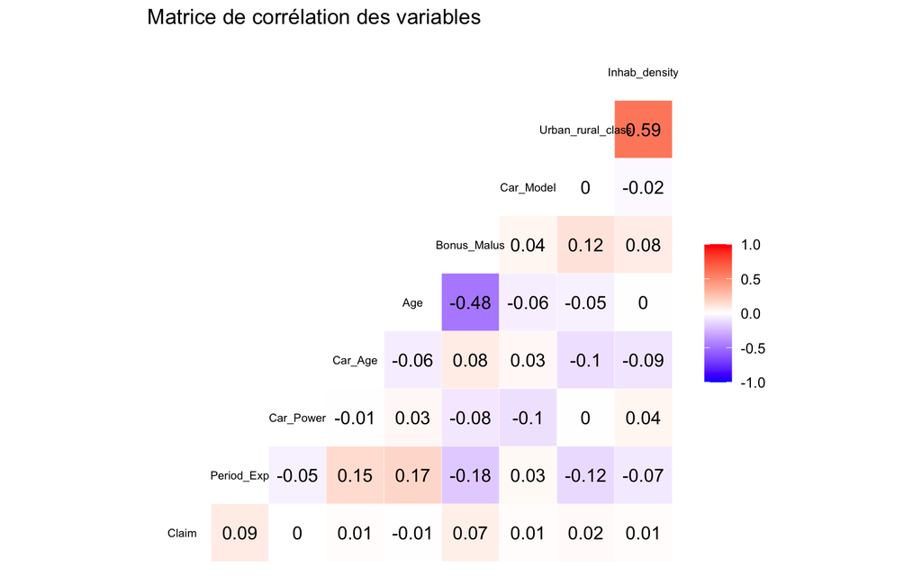

```r
# Convertir les variables catégorielles en nombres
train$Car_Model <- as.numeric(train$Car_Model)
train$Urban_rural_class <- as.numeric(train$Urban_rural_class)

ggcorr(train, label = TRUE, label_round = 2, low = "blue", mid = "white", high = "red", size = 2.5) +
  ggtitle("Matrice de corrélation des variables") +
  theme(axis.text.x = element_text(angle = 40, hjust = 0,5, size = 3),
        axis.text.y = element_text(size = 2))
```

Après analyse de la matrice, on remarque une corrélation négative entre l’âge du conducteur `Age` et le coefficient `Bonus_Malus` (-0.48) est significative. Elle traduit le fait que les conducteurs plus jeunes ont tendance à accumuler plus de malus, tandis que les conducteurs plus expérimentés bénéficient d’un bonus. Une autre relation forte apparaît entre la densité d’habitants `Inhab_density` et la classe urbaine `Urban_rural_class` (0.59), confirmant que les zones urbaines ont une densité de population plus élevée.

La variable cible `Claim` (nombre de sinistres) n’entretient que de faibles corrélations avec les autres variables. Par exemple, la période d’exposition `Period_Exp` est légèrement corrélée avec le nombre de sinistres (0.09), ce qui est intuitif : plus une assurance est active longtemps, plus elle a de chances d’être associée à un sinistre. Cependant, les autres variables, comme l’âge du conducteur, la puissance du véhicule `Car_Power` ou le type de carburant `Car_Fuel`, montrent des relations très faibles avec `Claim`, montrant que ces facteurs seuls n’expliquent pas directement la survenue des sinistres.

```r
# Revenir à des facteurs
train$Car_Model <- as.factor(train$Car_Model)
train$Urban_rural_class <- as.factor(train$Urban_rural_class)
str(train)
```

```
## 'data.frame':    542389 obs. of  11 variables:
##  $ Claim            : int  4 5 8 4 11 4 0 0 0 0 ...
##  $ Period_Exp       : num  0.56 1 0.41 0.27 0.08 0.1 0.96 0.73 0.09 0.73 ...
##  $ Car_Power        : int  4 7 4 5 4 4 14 10 4 5 ...
##  $ Car_Age          : int  4 9 12 9 13 1 25 2 12 4 ...
##  $ Age              : int  46 67 52 23 53 31 49 38 27 32 ...
##  $ Bonus_Malus      : int  50 50 50 90 50 85 50 51 68 50 ...
##  $ Car_Model        : Factor w/ 11 levels "1","2","3","4",..: 9 7 1 8 1 4 2 4 10 8 ...
##  $ Car_Fuel         : Factor w/ 2 levels "Diesel","Regular": 1 1 2 1 2 2 2 1 2 1 ...
##  $ Urban_rural_class: Factor w/ 6 levels "1","2","3","4",..: 1 5 4 5 4 5 5 3 3 3 ...
##  $ Inhab_density    : int  29 4762 824 6924 824 2983 5053 160 229 461 ...
##  $ French_region    : Factor w/ 22 levels "Alsace","Aquitaine",..: 7 21 13 12 13 17 12 20 6 6 ...
```

# 3 Échantillonnage

```r
set.seed(2025)

# Création de l'index pour séparer les données (80% train, 20% test)
trainIndex <- createDataPartition(train_scaled$Claim, p = 0.8, list = FALSE)

# Séparer les prédicteurs (X) et la variable cible (y)
X_train <- train_scaled[trainIndex, setdiff(names(train_scaled), "Claim")]
y_train <- train_scaled$Claim[trainIndex]

X_test <- train_scaled[-trainIndex, setdiff(names(train_scaled), "Claim")]
y_test <- train_scaled$Claim[-trainIndex]

# Affichage des tailles des ensembles
cat("📌 Taille du jeu d'entraînement :\n")
```

```
## 📌 Taille du jeu d'entraînement :
```

```r
cat("- X_train :", dim(X_train), "\n")
```

```
## - X_train : 433912 10
```

```r
cat("- y_train :", length(y_train), "\n\n")
```

```
## - y_train : 433912
```

```r
cat("📌 Taille du jeu de test :\n")
```

```
## 📌 Taille du jeu de test :
```

```r
cat("- X_test :", dim(X_test), "\n")
```

```
## - X_test : 108477 10
```

```r
cat("- y_test :", length(y_test), "\n")
```

```
## - y_test : 108477
```

```r
table(y_train)
```

```
## y_train
##      0      1      2      3      4      5      8     11
## 418046  14987    830     43      3      1      1      1
```

```r
table(y_test)
```

```
## y_test
##      0      1      2      3
## 104392   3870    208      7
```

```r
# Définition des classes basées sur la fréquence des valeurs de Claim
C_1 <- which(y_test %in% c(0, 1))
C_2 <- which(y_test == 2)
C_3 <- which(y_test == 3)
C_4 <- which(y_test > 3)
```

# 4 Modèle Régression de Poisson

```r
# Calcul de la moyenne et de la variance de Claim
mean_claim <- mean(train$Claim)
var_claim <- var(train$Claim)

cat("Moyenne de Claim :", mean_claim, "\n")
```

```
## Moyenne de Claim : 0.038937
```

```r
cat("Variance de Claim :", var_claim, "\n")
```

```
## Variance de Claim : 0.04221091
```

La variable cible Claim est une variable de type comptage (nombre de sinistres), souvent modélisée avec une loi de Poisson.Ainsi l’analyse des caractéristiques de la variable cible Claim montre que sa moyenne (0.0389) et sa variance (0.0422) sont très proches, ce qui est un bon indicateur de l’adéquation avec une distribution de Poisson.

```r
# Ajustement du modèle de Poisson sur le jeu d'entraînement
poisson_model1 <- glm(y_train ~ ., data = X_train, family = poisson(link = "log"))

# Résumé du modèle
summary(poisson_model1)
```

```
##
## Call:
## glm(formula = y_train ~ ., family = poisson(link = "log"), data = X_train)
##
## Coefficients:
##                                           Estimate Std. Error z value Pr(>|z|)
## (Intercept)                              -3.615997   0.136399 -26.511  < 2e-16
## Period_Exp                                0.551572   0.008975  61.457  < 2e-16
## Car_Power                                 0.085191   0.008407  10.133  < 2e-16
## Car_Age                                  -0.089021   0.009062  -9.823  < 2e-16
## Age                                       0.100914   0.008272  12.200  < 2e-16
## Bonus_Malus                               0.405760   0.006676  60.783  < 2e-16
## Car_ModelB10                             -0.031803   0.049223  -0.646 0.518209
## Car_ModelB11                              0.039387   0.054304   0.725 0.468266
## Car_ModelB12                             -0.376047   0.027954 -13.452  < 2e-16
## Car_ModelB13                             -0.010489   0.057106  -0.184 0.854274
## Car_ModelB14                             -0.273008   0.113650  -2.402 0.016297
## Car_ModelB2                              -0.001961   0.021378  -0.092 0.926923
## Car_ModelB3                               0.034073   0.029869   1.141 0.253969
## Car_ModelB4                               0.041358   0.040279   1.027 0.304529
## Car_ModelB5                               0.051975   0.034741   1.496 0.134640
## Car_ModelB6                              -0.001139   0.038973  -0.029 0.976676
## Car_FuelRegular                          -0.155324   0.015971  -9.725  < 2e-16
## Urban_rural_classB                        0.075083   0.033138   2.266 0.023464
## Urban_rural_classC                        0.148101   0.027416   5.402 6.59e-08
## Urban_rural_classD                        0.291856   0.028987  10.068  < 2e-16
## Urban_rural_classE                        0.372534   0.037600   9.908  < 2e-16
## Urban_rural_classF                        0.430489   0.129400   3.327 0.000878
## Inhab_density                             0.002961   0.021082   0.140 0.888313
## French_regionAquitaine                    0.069333   0.138252   0.501 0.616022
## French_regionAuvergne                     0.098011   0.166605   0.588 0.556344
## French_regionBasse-Normandie              0.143493   0.144566   0.993 0.320913
## French_regionBourgogne                    0.024104   0.149653   0.161 0.872040
## French_regionBretagne                     0.136264   0.135816   1.003 0.315715
## French_regionCentre                       0.062455   0.133915   0.466 0.640946
## French_regionChampagne-Ardenne            0.253947   0.185361   1.370 0.170682
## French_regionCorse                        0.306621   0.168519   1.819 0.068836
## French_regionFranche-Comte                0.008357   0.236881   0.035 0.971857
## French_regionHaute-Normandie             -0.087938   0.157261  -0.559 0.576036
## French_regionIle-de-France                0.051108   0.135946   0.376 0.706961
```

[output cut: 50 more lines]

```
## French_regionPays-de-la-Loire
## French_regionPicardie
## French_regionPoitou-Charentes
## French_regionProvence-Alpes-Cotes-D'Azur
## French_regionRhone-Alpes                 *
## ---
## Signif. codes:  0 '***' 0.001 '**' 0.01 '*' 0.05 '.' 0.1 ' ' 1
##
## (Dispersion parameter for poisson family taken to be 1)
##
##     Null deviance: 112023  on 433911  degrees of freedom
## Residual deviance: 104298  on 433868  degrees of freedom
## AIC: 136680
##
## Number of Fisher Scoring iterations: 6
```

```r
dispersion <- sum(residuals(poisson_model1, type = "pearson")^2) / poisson_model1$df.residual
cat("Indice de dispersion :", dispersion, "\n")
```

```
## Indice de dispersion : 1.097676
```

```r
# Prédictions
y_train_pred1 <- predict(poisson_model1, newdata = X_train, type = "response")
y_test_pred1 <- predict(poisson_model1, newdata = X_test, type = "response")

# Arrondir les prédictions
y_train_pred1_round <- round(y_train_pred1)
y_test_pred1_round <- round(y_test_pred1)
```

```r
# Calcul du RMSE pour chaque classe (prédictions train arrondies)
rmse_1_train <- ifelse(length(C_1) > 0, rmse(y_train[C_1], y_train_pred1[C_1]), NA)
rmse_2_train <- ifelse(length(C_2) > 0, rmse(y_train[C_2], y_train_pred1[C_2]), NA)
rmse_3_train <- ifelse(length(C_3) > 0, rmse(y_train[C_3], y_train_pred1[C_3]), NA)
rmse_4_train <- ifelse(length(C_4) > 0, rmse(y_train[C_4], y_train_pred1[C_4]), NA)

# Calcul du RMSE combiné train
RMSE_c_train <- mean(c(rmse_1_train, rmse_2_train, rmse_3_train, rmse_4_train), na.rm = TRUE)

# Calcul du RMSE pour chaque classe (prédictions test non arrondies)
rmse_1 <- ifelse(length(C_1) > 0, rmse(y_test[C_1], y_test_pred1[C_1]), NA)
rmse_2 <- ifelse(length(C_2) > 0, rmse(y_test[C_2], y_test_pred1[C_2]), NA)
rmse_3 <- ifelse(length(C_3) > 0, rmse(y_test[C_3], y_test_pred1[C_3]), NA)
rmse_4 <- ifelse(length(C_4) > 0, rmse(y_test[C_4], y_test_pred1[C_4]), NA)

# Calcul du RMSE combiné test
RMSE_c1 <- mean(c(rmse_1, rmse_2, rmse_3, rmse_4), na.rm = TRUE)

# Calcul du RMSE pour chaque classe (prédictions arrondies)
rmse_1_rounded <- ifelse(length(C_1) > 0, rmse(y_test[C_1], y_test_pred1_round[C_1]), NA)
rmse_2_rounded <- ifelse(length(C_2) > 0, rmse(y_test[C_2], y_test_pred1_round[C_2]), NA)
rmse_3_rounded <- ifelse(length(C_3) > 0, rmse(y_test[C_3], y_test_pred1_round[C_3]), NA)
rmse_4_rounded <- ifelse(length(C_4) > 0, rmse(y_test[C_4], y_test_pred1_round[C_4]), NA)

# Calcul du RMSE combiné test après arrondi
RMSE_c_rounded1 <- mean(c(rmse_1_rounded, rmse_2_rounded, rmse_3_rounded, rmse_4_rounded), na.rm = TRUE)

# Affichage des résultats
cat("📊 RMSE combiné train:", RMSE_c_train, "\n")
```

```
## 📊 RMSE combiné train: 0.05172419
```

```r
cat("📊 RMSE combiné test :", RMSE_c1, "\n")
```

```
## 📊 RMSE combiné test : 1.688574
```

```r
cat("📊 RMSE combiné test arrondi :", RMSE_c_rounded1, "\n")
```

```
## 📊 RMSE combiné test arrondi : 1.729852
```

```r
# Ajustement du modèle réduit de Poisson
poisson_model_reduit <- glm(y_train ~ . -Car_Model - Inhab_density -French_region +Age:Bonus_Malus,
                            family = poisson(link = "log"),
                            data = X_train)

# Résumé du modèle réduit
summary(poisson_model_reduit)
```

```
##
## Call:
## glm(formula = y_train ~ . - Car_Model - Inhab_density - French_region +
##     Age:Bonus_Malus, family = poisson(link = "log"), data = X_train)
##
## Coefficients:
##                     Estimate Std. Error  z value Pr(>|z|)
## (Intercept)        -3.588535   0.023315 -153.915  < 2e-16 ***
## Period_Exp          0.585452   0.008776   66.707  < 2e-16 ***
## Car_Power           0.070355   0.007815    9.003  < 2e-16 ***
## Car_Age            -0.032062   0.008187   -3.916 8.99e-05 ***
## Age                 0.087850   0.008452   10.394  < 2e-16 ***
## Bonus_Malus         0.410858   0.006891   59.619  < 2e-16 ***
## Car_FuelRegular    -0.174698   0.015820  -11.043  < 2e-16 ***
## Urban_rural_classB  0.091075   0.032730    2.783  0.00539 **
## Urban_rural_classC  0.176396   0.026395    6.683 2.34e-11 ***
## Urban_rural_classD  0.321496   0.026946   11.931  < 2e-16 ***
## Urban_rural_classE  0.407351   0.027427   14.852  < 2e-16 ***
## Urban_rural_classF  0.340922   0.050652    6.731 1.69e-11 ***
## Age:Bonus_Malus     0.013587   0.005533    2.456  0.01406 *
## ---
## Signif. codes:  0 '***' 0.001 '**' 0.01 '*' 0.05 '.' 0.1 ' ' 1
##
## (Dispersion parameter for poisson family taken to be 1)
##
##     Null deviance: 112023  on 433911  degrees of freedom
## Residual deviance: 104760  on 433899  degrees of freedom
## AIC: 137079
##
## Number of Fisher Scoring iterations: 6
```

```r
dispersion <- sum(residuals(poisson_model_reduit, type = "pearson")^2) / poisson_model1$df.residual
cat("Indice de dispersion :", dispersion, "\n")
```

```
## Indice de dispersion : 1.09388
```

```r
# Prédictions
y_train_pred2 <- predict(poisson_model_reduit, newdata = X_train, type = "response")
y_test_pred2 <- predict(poisson_model_reduit, newdata = X_test, type = "response")

# Arrondir les prédictions
y_train_pred2_round <- round(y_train_pred2)
y_test_pred2_round <- round(y_test_pred2)
```

```r
# Calcul du RMSE pour chaque classe (prédictions arrondies)
rmse_21_rounded <- ifelse(length(C_1) > 0, rmse(y_test[C_1], y_test_pred2_round[C_1]), NA)
rmse_22_rounded <- ifelse(length(C_2) > 0, rmse(y_test[C_2], y_test_pred2_round[C_2]), NA)
rmse_23_rounded <- ifelse(length(C_3) > 0, rmse(y_test[C_3], y_test_pred2_round[C_3]), NA)
rmse_24_rounded <- ifelse(length(C_4) > 0, rmse(y_test[C_4], y_test_pred2_round[C_4]), NA)

# Calcul du RMSE combiné après arrondi
RMSE_c2_rounded <- mean(c(rmse_21_rounded, rmse_22_rounded, rmse_23_rounded, rmse_24_rounded), na.rm = TRUE)

# Affichage des résultats
cat("📊 RMSE combiné :", RMSE_c2_rounded, "\n")
```

```
## 📊 RMSE combiné : 1.729803
```

# 5 Modélisation avec la régression binomiale négative

La régression binomiale négative est une extension de la régression de Poisson, adaptée aux données présentant une sur-dispersion.

```r
# Modèle binomial négatif
nb_model <- glm.nb(y_train ~ ., data =  X_train)
summary(nb_model)
```

```
##
## Call:
## glm.nb(formula = y_train ~ ., data = X_train, init.theta = 1.058951894,
##     link = log)
##
## Coefficients:
##                                           Estimate Std. Error z value Pr(>|z|)
## (Intercept)                              -3.634233   0.141485 -25.686  < 2e-16
## Period_Exp                                0.550824   0.009207  59.828  < 2e-16
## Car_Power                                 0.084549   0.008640   9.785  < 2e-16
## Car_Age                                  -0.087687   0.009308  -9.420  < 2e-16
## Age                                       0.102312   0.008605  11.890  < 2e-16
## Bonus_Malus                               0.406604   0.007222  56.301  < 2e-16
## Car_ModelB10                             -0.031814   0.050712  -0.627 0.530439
## Car_ModelB11                              0.036862   0.056030   0.658 0.510598
## Car_ModelB12                             -0.373952   0.028602 -13.074  < 2e-16
## Car_ModelB13                             -0.015244   0.058893  -0.259 0.795763
## Car_ModelB14                             -0.274996   0.116333  -2.364 0.018085
## Car_ModelB2                              -0.001673   0.022014  -0.076 0.939428
## Car_ModelB3                               0.034575   0.030800   1.123 0.261626
## Car_ModelB4                               0.043948   0.041494   1.059 0.289540
## Car_ModelB5                               0.053811   0.035859   1.501 0.133455
## Car_ModelB6                              -0.001221   0.040163  -0.030 0.975748
## Car_FuelRegular                          -0.155878   0.016429  -9.488  < 2e-16
## Urban_rural_classB                        0.075268   0.033917   2.219 0.026474
## Urban_rural_classC                        0.149875   0.028065   5.340 9.29e-08
## Urban_rural_classD                        0.295097   0.029729   9.926  < 2e-16
## Urban_rural_classE                        0.375171   0.038663   9.704  < 2e-16
## Urban_rural_classF                        0.440057   0.133345   3.300 0.000966
## Inhab_density                             0.002750   0.021751   0.126 0.899405
## French_regionAquitaine                    0.083100   0.143347   0.580 0.562110
## French_regionAuvergne                     0.114116   0.171924   0.664 0.506846
## French_regionBasse-Normandie              0.164323   0.149856   1.097 0.272841
## French_regionBourgogne                    0.040962   0.154917   0.264 0.791465
## French_regionBretagne                     0.153784   0.140923   1.091 0.275158
## French_regionCentre                       0.077403   0.138971   0.557 0.577548
## French_regionChampagne-Ardenne            0.272746   0.190936   1.428 0.153158
## French_regionCorse                        0.324253   0.173886   1.865 0.062217
## French_regionFranche-Comte                0.027104   0.243255   0.111 0.911281
## French_regionHaute-Normandie             -0.071277   0.162321  -0.439 0.660581
```

[output cut: 57 more lines]

```
## Signif. codes:  0 '***' 0.001 '**' 0.01 '*' 0.05 '.' 0.1 ' ' 1
##
## (Dispersion parameter for Negative Binomial(1.059) family taken to be 1)
##
##     Null deviance: 99198  on 433911  degrees of freedom
## Residual deviance: 91842  on 433868  degrees of freedom
## AIC: 136324
##
## Number of Fisher Scoring iterations: 1
##
##
##               Theta:  1.0590
##           Std. Err.:  0.0729
##
##  2 x log-likelihood:  -136234.4090
```

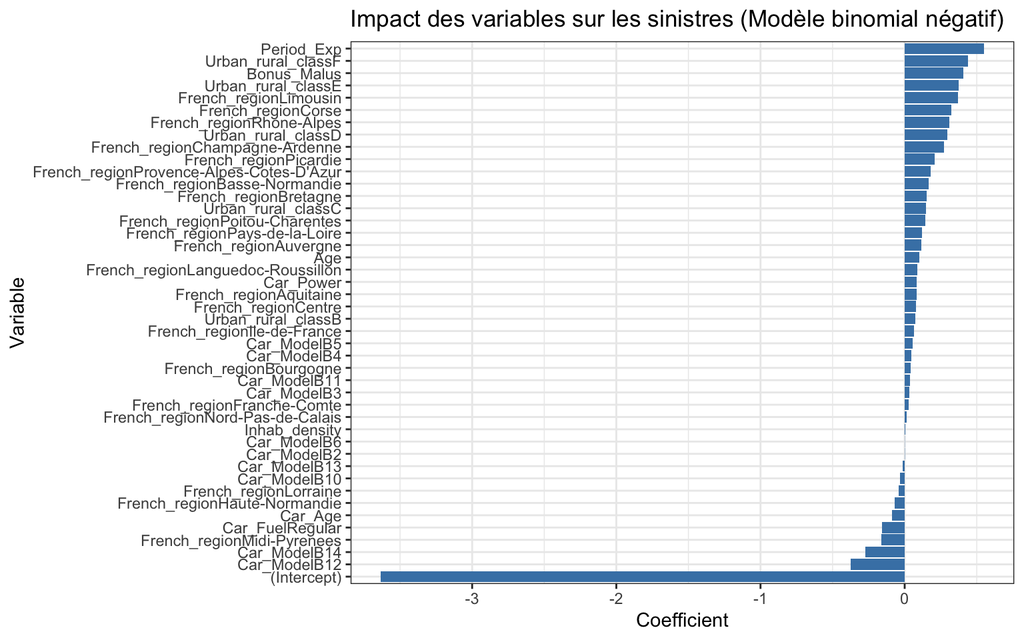

```r
# Extraction des coefficients du modèle complet
coef_df <- as.data.frame(summary(nb_model)$coefficients)
coef_df$Variable <- rownames(coef_df)

# Visualisation des coefficients (impact des variables)
ggplot(coef_df, aes(x = reorder(Variable, Estimate), y = Estimate)) +
  geom_bar(stat = "identity", fill = "steelblue") +
  coord_flip() +
  theme_bw() +
  labs(title = "Impact des variables sur les sinistres (Modèle binomial négatif)",
       x = "Variable", y = "Coefficient")
```

Pour choisir le meilleur modèle, on compare les critères de sélection comme l’AIC ou le BIC et les mesures de performance (ex: RMSE_C):

```r
# Comparaison des AIC pour le modèle de Poisson et le modèle binomial négatif
AIC(poisson_model1, nb_model)
```

```
##                df      AIC
## poisson_model1 44 136679.8
## nb_model       45 136324.4
```

```r
# Prédictions sur le jeu d'entraînement
y_train_pred4 <- predict(nb_model, newdata = X_train, type = "response")
y_test_pred4 <- predict(nb_model, newdata = X_test, type = "response")
y_train_pred4_round <- round(y_train_pred4)
y_test_pred4_round <- round(y_test_pred4)
```

```r
# Calcul du RMSE pour chaque classe
rmse_41 <- ifelse(length(C_1) > 0, rmse(y_test[C_1], y_test_pred4_round[C_1]), NA)
rmse_42 <- ifelse(length(C_2) > 0, rmse(y_test[C_2], y_test_pred4_round[C_2]), NA)
rmse_43 <- ifelse(length(C_3) > 0, rmse(y_test[C_3], y_test_pred4_round[C_3]), NA)
rmse_44 <- ifelse(length(C_4) > 0, rmse(y_test[C_4], y_test_pred4_round[C_4]), NA)

# Calcul du RMSE combiné (moyenne des RMSE des différentes classes)
RMSE_c4 <- mean(c(rmse_41, rmse_42, rmse_43, rmse_44), na.rm = TRUE)

# Affichage du résultat
cat("📊 RMSE combiné:", RMSE_c4, "\n")
```

```
## 📊 RMSE combiné: 1.729852
```